# Formation au carroyage et lissage spatial sur R

Kévin Milin et Solène Colin

Dernière modification : septembre 2026

# Bienvenue dans cet espace de formation !

En 2018, le PSAR analyse urbaine, ancêtre de la section analyse urbaine à la direction générale de l’Insee, a développé un package R, nommé `btb` (auteurs : Arlindo Dos Santos et François Sémécurbe).

Sa principale fonction, `btb_smooth`, permet de réaliser très facilement un **carroyage** et un **lissage** sur des données géolocalisées avec R.

À partir de données ponctuelles, nous allons apprendre en utilisant le langage R :

- À carroyer les informations.
- À réaliser des lissages de densité, des lissages de moyennes, des lissages de taux et des lissages quantiles.
- À calculer un indicateur sur une zone à façon à partir des données carroyées de l’Insee.

## Liens utiles

- Code de la formation : https://github.com/InseeFrLab/formation-r-lissage-spatial
- Site web des supports de formation : https://inseefrlab.github.io/formation-r-lissage-spatial
  - Tutoriel
  - Diaporama
  - Exercices

## Crédits (Division Statistiques et Analyses Urbaines)

- Cette formation s’inspire d’une formation élaborée par Arlindo Dos Santos en 2018-2019
- Elle a été refondue par Julien Pramil principalement, et Kim Antunez en co-animatrice, en 2021 en y intégrant, notamment, les données en open-data DVF
- Elle est animée depuis 2024 par Solène Colin avec l’appui de Kévin Milin

**Pour réaliser les exercices depuis la plateforme SSPCloud du Service Statistique Public** :

- Aller sur le SSPCloud : https://datalab.sspcloud.fr/ ;
- Se connecter avec son adresse mail insee et son mot de passe ;
- Cliquer sur **Trainings** en haut à droite de la page d’accueil ;
- Trouver la formation **Carroyage et lissage spatial sur R** dans la partie **Tutoriels de data science** et cliquer sur **ouvrir** ;

Les différentes parties de la présentation sont accessibles via le bouton **Lire**. Pour réaliser l’exercice, vous pouvez ouvrir l’environnement RStudio préconfiguré en cliquant sur **Lancer**.

[figure not shown]

- Attendre le chargement
- Cliquer sur « **First, copy the service** »

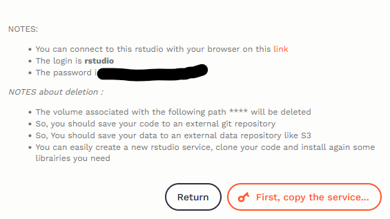

- Cliquer sur « **Open the service** »
- Cliquer sur « **Copy the password** »

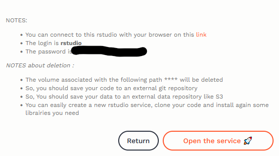

- Authentifiez-vous avec :
  - l’identifiant : « **rstudio** »
  - le mdp copié précédemment à l’aide d’un CTRL+V
  - Puis Sign in !

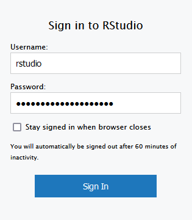

Et voilà, votre session RStudio préconfigurée est prête !

Vous pouvez maintenant écrire du code R en ouvrant un nouveau script vierge (CTRL+MAJ+N).